# Naple Reef Treatments on Purple Urchin Sizes

Kiera Matiska

10/28/2021

# Objective:

This code wrangles and visualizes data on how the two different treatment groups in the Naples Reef affect the size of Purple Urchins.

### Source:

Reed, D. 2020. SBC LTER: Reef: Long-term experiment: Kelp removal: Urchin size frequency distribution ver 20. Environmental Data Initiative. https://doi.org/10.6073/pasta/5a1e9ef03aa47bd2225c0bb98a02a63b.

# Read in and clean up data

Use the ‘read_csv()’ and the ‘here()’ functions to read in urchins.csv.

```r
urchins <- read_csv(here("data", "urchins.csv")) # Read in data
```

# Clean up data

Use the ‘clean_names()’ in the janitor package to change the column headers into lower_snake_case.

```r
urchins_clean <- urchins %>%
  clean_names() # Change column header titles to lower case letters
```

# Compare Data

Compare the mean size of purple urchins in two different sections of Naples Reef: no giant kelp removal and annual kelp removal. Data is from 2010.

### Wrangle Data

- Use the ‘myd()’ function in the lubridate package to convert the date to date class
- Use the ‘mutate()’ function to create a new column with the year using ‘year()’
- Use the ‘filter()’ function to separate observations that include three criteria: the species is purple urchin, the year is 2010, and the site NAPL for Naples Reef

```r
naple_purple <- urchins_clean %>%
  mutate(date = myd(date)) %>% # Change class in date column
  mutate(year = year(date)) %>% # Add a year column
  filter(site == "NAPL", common_name == "Purple Urchin", year == "2010") # Filter for specific observations
```

### Data Visualization

Create a histogram comparing the size distribution of purple urchins at Naples in 2010, faceted by treatment

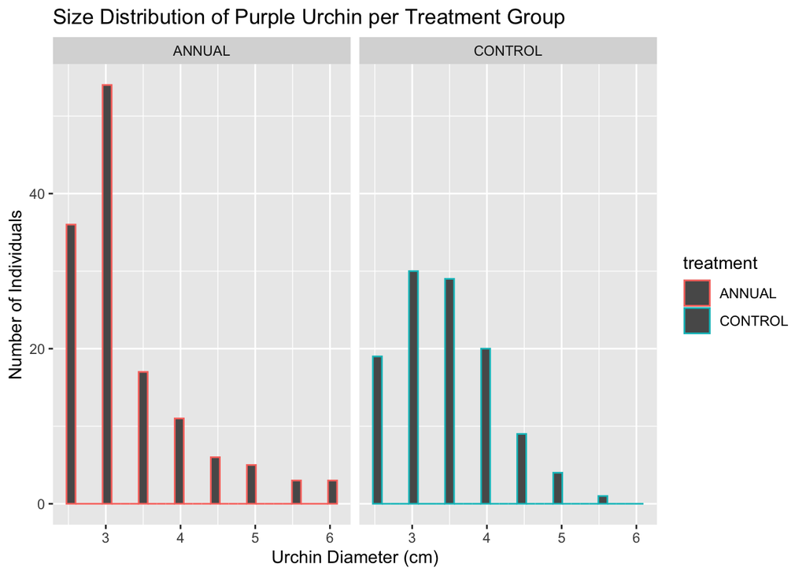

```r
ggplot(data = naple_purple,
       aes(x = size, color = treatment)) + # Change color of graph data
  geom_histogram() + # Histogram
  facet_wrap(~ treatment) + # Separated by treatment group
  labs(title = "Size Distribution of Purple Urchin per Treatment Group",
       x = "Urchin Diameter (cm)",
       y = "Number of Individuals") # Added labels
```

Create a QQ-plot comparing the size distribution of purple urchins at Naples in 2010, faceted by treatment

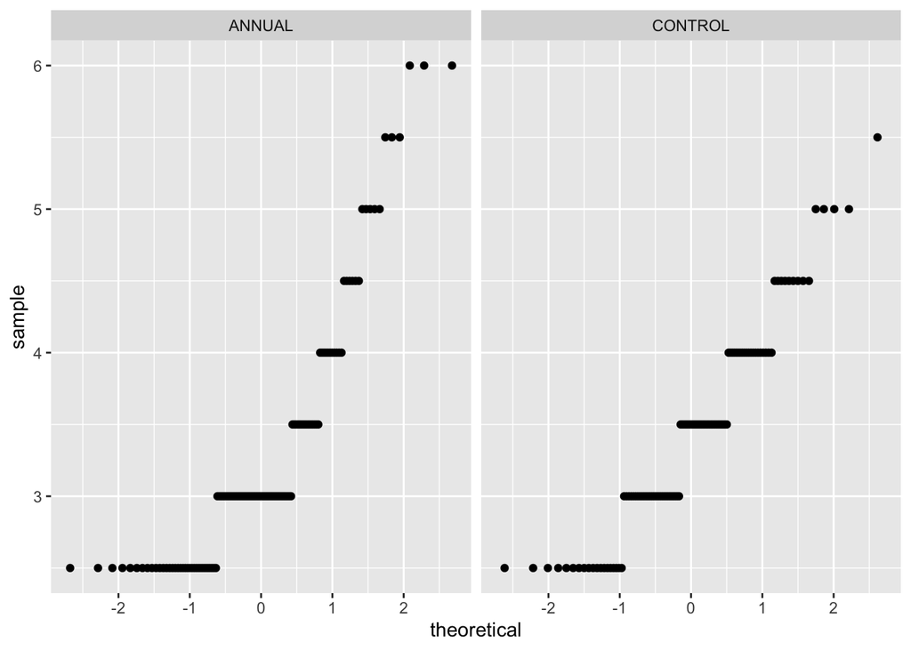

```r
ggplot(data = naple_purple,
       aes(sample = size)) +
  geom_qq() + # Created a qq-plot
  facet_wrap(~ treatment) # Separated data by treatment group
```

Between the two treatments, the one where kelp was removed annually appears to have more of a size spread and a higher population than the control treatment group, where there is no giant kelp removal. Given this data, it is likely that there is a healthier ecosystem for the treatment group (annual kelp removal), which can support more individuals.

### Create a statistics table

Using the ‘summarize()’ function, create a descriptive table comparing: - mean - standard deviation - sample size of each treatment.

Finalize the table with the kableExtra package and add a caption above it.

```r
naple_purple_sum <- naple_purple %>%
  group_by(treatment) %>% #Splits the table into control and treatment
  summarize(mean(size),
            sd(size),
            sample_size = n())

naple_purple_sum %>%
  kbl(caption = "Table 1: Statistical data, including mean, standard deviation, and sample sizes, of Purple Urchin size under different treatment groups at different sites in the Naple Reef") %>%
  kable_styling()
```

Table 1: Statistical data, including mean, standard deviation, and sample sizes, of Purple Urchin size under different treatment groups at different sites in the Naple Reef

| treatment | mean(size) | sd(size) | sample_size |
| --- | --- | --- | --- |
| ANNUAL | 3.274074 | 0.8346921 | 135 |
| CONTROL | 3.437500 | 0.6914048 | 112 |